# Communautés piscicoles de la rivière Doubs

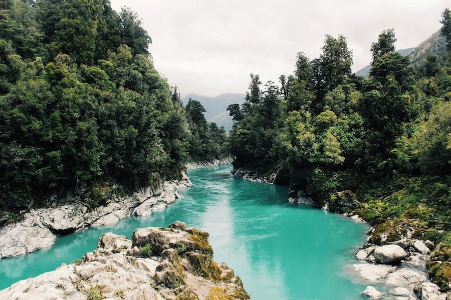

Photo domaine public par Dom Gould.

Le [Doubs](http://www.cosmovisions.com/Doubs.htm) (prononcez “dou”) est une rivière qui serpente entre la France et la Suisse pour se jeter finalement dans la Saône près de Chalon-sur-Saône (point noir sur la carte ci-dessous) après avoir parcouru près de 450 km.

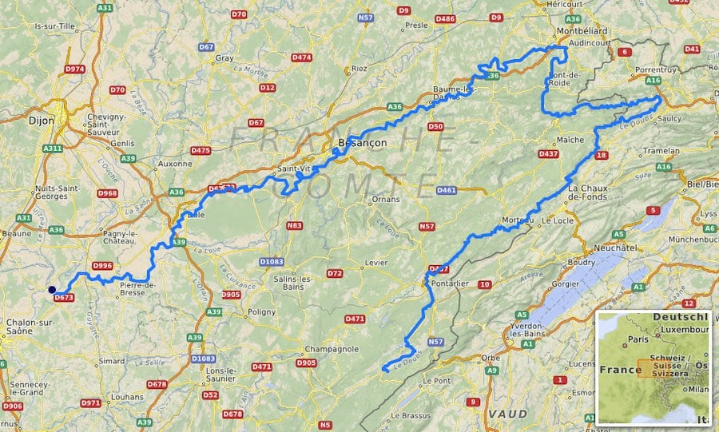

Carte du Doubs, d’après OpenStreetMap.

La distribution des poissons est étudiée dans cette rivière (Verneaux 1973, 2003). Pour ce faire, 30 stations sont échantillonnées tout au long de son cours. Elles sont numérotées dans l’ordre de 1 à 30 le long de son cours jusqu’à ce que la rivière se déverse dans la Saône (après la station 30).

À chaque station, les hommes de terrain ont effectué une collecte des poissons présents et les ont dénombrés. Au total, ils ont pu observer 27 espèces différentes.

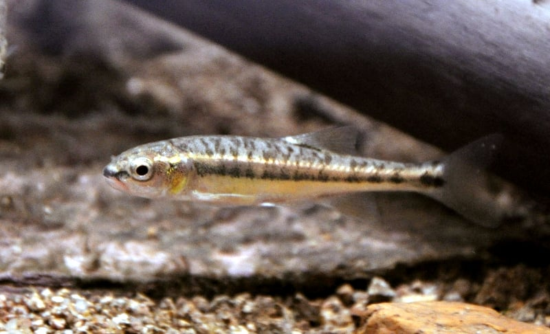

Le vairon *Phoxinus phoxinus*, une des espèces les plus abondantes dans le Doubs. Domaine public, photo de Adrien Pinot.

Vous vous doutez bien que plusieurs micro-habitats différents peuvent exister tout au long de cette longue rivière. Par ailleurs, une variation progressive d’une station à l’autre est également parfaitement possible ici. Votre travail va consister en une exploration multivariée du jeu de données pour proposer sa segmentation en micro-habitats différents caractérisés par des conditions physico-chimiques et/ou des compositions en faune piscicole différentes.

Vous avez à disposition l’article de 2003 de Verneaux, ainsi qu’un court article sur la typologie des cours d’eaux (Anonyme, 2018) et une vidéo sur le Doubs https://www.ina.fr/video/CAF93027933 pour cerner le sujet. Ces références sont anciennes, mais contemporaines au jeu de données que vous allez analyser.

## Références

Anonyme (2018) Les typologies des cours d’eau. *AFB*, 1-4.

Verneaux, J. (1973) Cours d’eau de Franche-Comté (Massif du Jura). Recherches écologiques sur le réseau hydrographique du Doubs. Essai de biotypologie. Thèse d’état, Besançon. 1–257.

Verneaux, J. (2003) Benthic insects and fish of the Doubs River system: typological traits and the development of a species continuum in a theoretically extrapolated watercourse. *Hydrobiologia*, 490:63-74.